# Module 11

# Type I and II Errors and Statistical Power

## Preliminaries

- Install these packages in *R*: {curl}, {ggplot2}, {manipulate}

## Objectives

> The objective of this module is to discuss the concepts of Type I and Type II error, the multiple testing problem, statistical power, and effect size and outline how we can use *R* to investigate these via simulation and built-in functions.

## Overview

Let's return to the concepts of **error** and **power**. Recall that Type I error occurs when you **incorrectly reject a true *H*<sub>0</sub>**. In any given hypothesis test, the probability of a Type I error is equivalent to the significance level, *α*, and it is this type of error we are often trying to minimize when we are doing classical statistical inference. Type II error occurs when you **incorrectly fail to reject a false *H*<sub>0</sub>** (in other words, fail to find evidence in support of a true *H*<sub>*A*</sub>). Since we do not know what the true *H*<sub>*A*</sub> actually is, the probability of committing such an error, labeled *β*, is not usually known in practice.

| What is True | What We Decide | Result |
| --- | --- | --- |
| *H*<sub>0</sub> | *H*<sub>0</sub> | Correctly 'accept' the null |
| *H*<sub>0</sub> | *H*<sub>*A*</sub> | Falsely reject the null (Type I error) |
| *H*<sub>*A*</sub> | *H*<sub>0</sub> | Falsely 'accept' the null (Type II error) |
| *H*<sub>*A*</sub> | *H*<sub>*A*</sub> | Correctly reject the null |

## Type I Error and the Multiple Testing Problem

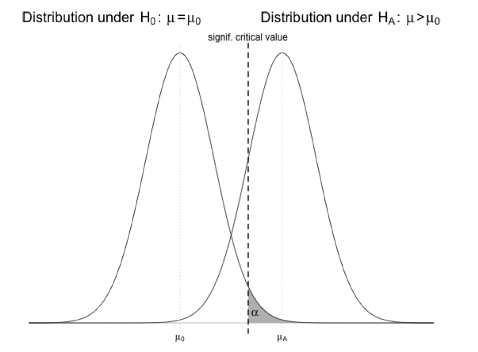

Let's explore this via simulation.

We will write some code to simulate a bunch of random datasets from a normal distribution where we set the expected population mean (*μ*<sub>0</sub>) and standard deviation (*σ*) and then calculate a Z (or T) statistic and p value for each one. We will then look at the "Type I" error rate... the proportion of times that, based on our sample, we would conclude that it was not drawn from the distribution we know to be true.